# Modelagem da Febre Amarela

S. Simon

October 19, 2018

## INTRODUÇÃO

O documento a seguir apresenta uma análise dos dois eventos de epizootia de Febre Amarela ocorridos no Brasil entre 1999 e 2018. Após o tratamento dos dados, o R0 dos dois eventos é estimado a partir do ajuste de uma curva exponencial aos dados. Em seguida, é executada uma simulação do modelo SIR-SEI para o cenário ocorrido em 2016-2018 no Espírito Santo, utilizando os parâmetros para Febre Amarela em humanos propostos por Massad et al, 2018.

### Estimando o R0 para as epizootias de Febre Amarela de 2008 e 2017

Para estimar o R0, serão utilizados todos os registros de óbitos de pnh por febre amarela no Brasil, de 1999 a 2018, sem discriminar espécies ou estados onde ocorreram as epizootias.

```r
# lendo os dados:
dados <- read.csv("pnh_1999-2018.csv")
names(dados)
```

```
##  [1] "data"       "mês"        "ano"        "uf"         "HASC_1"
##  [6] "cod.ibge"   "municipio"  "longitude"  "latitude"   "n.animais"
## [11] "gen.id"     "CALLITHRIX" "SAPAJUS"    "CEBUS"      "ALOUATTA"
## [16] "SAIMIRI"    "outro"
```

```r
fa <- data.frame(dados$data, dados$municipio, dados$uf, dados$n.animais)
names(fa) <- c("data","municipio","uf","casos")
```

Como os óbitos foram registrados por data, vamos converter as datas em número de dias.

```r
library(lubridate)
library(dplyr)
```

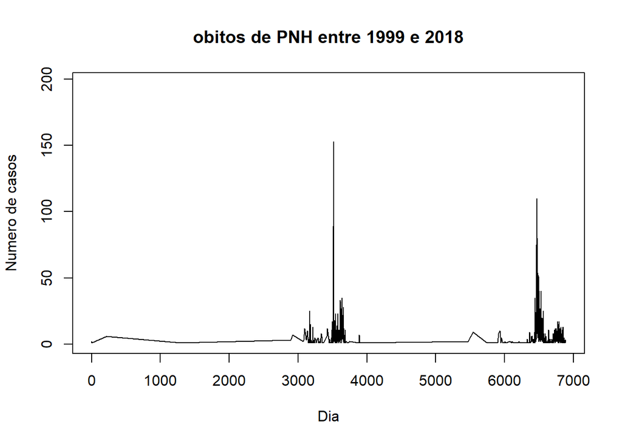

```r
# Convertendo data em vetor de valores inteiros (= contagem de dias):
fa$data <- ymd(fa$data)
fa <- arrange(fa,data)

inicio <- fa[1,1]
nextday <- as.integer(fa[,1] - inicio)
dia <- nextday+1
fa0 <- data.frame(fa,dia)

# Nesse novo df, agrupar o número de registros por dia:
fa0 <- group_by(fa0, dia)
curve <- summarise(fa0,sum(casos))
names(curve) <- c("dia", "casos")

plot(y = curve$casos, x = curve$dia, type="l", main = "obitos de PNH entre 1999 e 2018", xlab = "Dia", ylab = "Numero de casos")
```

### Epidemia 2008 - 2009

Para conhecer o R0 é necessário selecionar um periodo na fase de crescimento, separando dados da subida da curva para o ajuste.

```r
# Selecionando dados
summary(curve) # pico = 153 casos no dia 3518.
```

```
##       dia           casos
##  Min.   :   1   Min.   :  1.000
##  1st Qu.:3591   1st Qu.:  2.000
##  Median :6442   Median :  4.000
##  Mean   :5366   Mean   :  8.206
##  3rd Qu.:6640   3rd Qu.:  9.000
##  Max.   :6887   Max.   :197.000
##  NA's   :1
```

```r
curve3 <- curve[curve$dia>=3460 & curve$dia<=3515,]
names(curve3) <- c("dia","casos")
t <- c(curve3$dia-3460)
curve3 <- data.frame(curve3, t)
head(curve3,2)
```

|  | dia | casos | t |
| --- | --- | --- | --- |
| 1 | 3461 | 4 | 1 |
| 2 | 3465 | 1 | 5 |

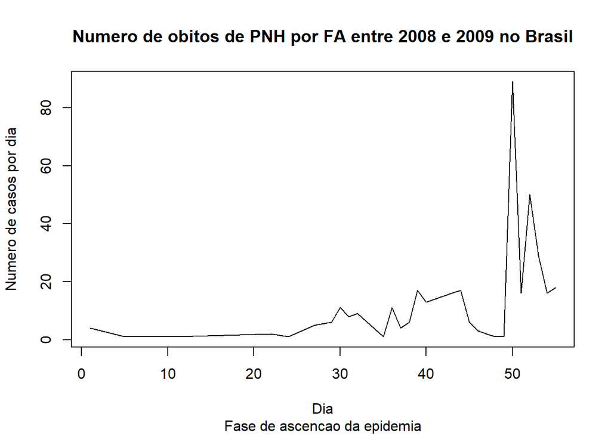

```r
plot(curve3$t, curve3$casos, type= "l", ylab = "Numero de casos por dia", xlab = "Dia",
     main = "Numero de obitos de PNH por FA entre 2008 e 2009 no Brasil",
     sub = "Fase de ascencao da epidemia")
```

O registro de óbitos apresenta um padrão variável que não é característico de uma curva exponencial. Vamos agrupar os registros por intervalos de tempo semanal, sendo a semana 1 aquela em que começou a epizootia (não corresponde necessariamente à semanas epidemiológicas).

```r
sem <- c((curve3$t %/% 7)+1) # x %/% y = Parte inteira da divisão de x por y
curve4 <- data.frame(curve3$casos, sem)
curve4 <- group_by(curve4, sem)
curve4 <- summarise(curve4, sum(curve3.casos))
names(curve4) <- c("sem", "casos")
```

O ajuste da subida da curva é feito utilizando uma função exponencial Ch x exp(k x tempo) onde Ch e k sao parametros de ajuste. O valor inicial de Ch é um chute para o numero de casos inicial.

```r
ajuFA1 <- nls(casos ~ Ch*exp(k*sem), data = curve4,
             start = list(Ch=1, k=1), # chute inicial
             trace = TRUE)
```

```
## 8873154 :  1 1
## 7477.65 :  0.04726015 1.00301454
## 2637.235 :  0.04712223 1.06269867
## 2244.53 :  0.04186179 1.06669452
## 2243.921 :  0.04139597 1.06853418
## 2243.916 :  0.04117868 1.06920866
## 2243.915 :  0.04109861 1.06945759
## 2243.915 :  0.04106899 1.06954945
## 2243.915 :  0.04105806 1.06958330
## 2243.915 :  0.04105403 1.06959580
```

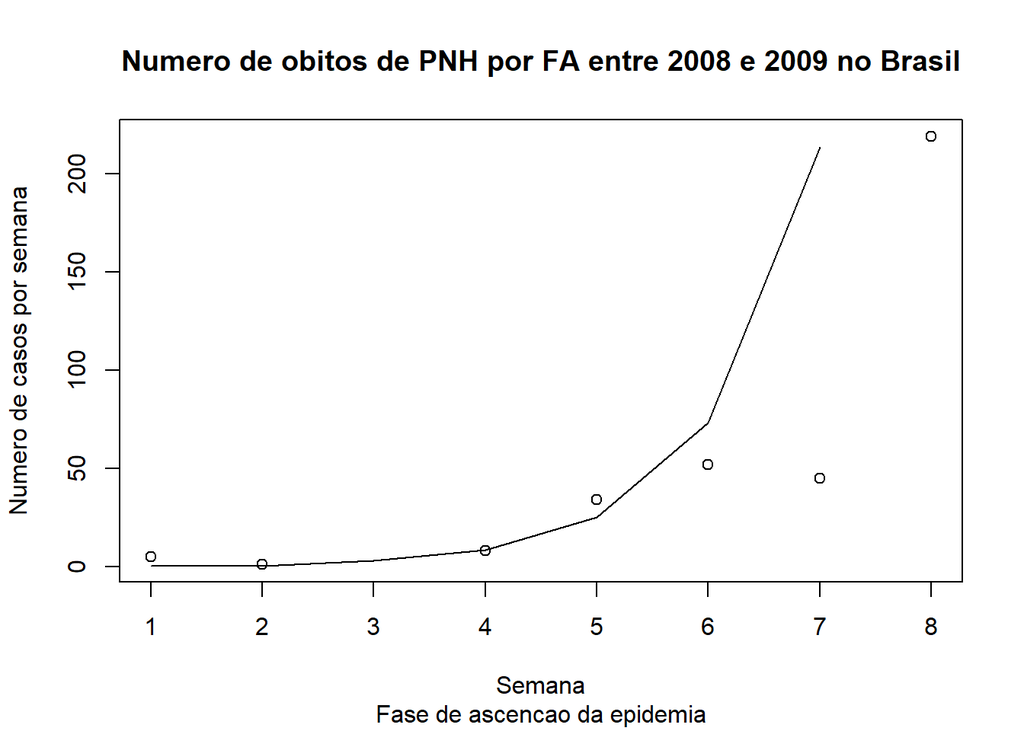

```r
plot(curve4$sem, curve4$casos, ylab = "Numero de casos por semana", xlab = "Semana",
     main = "Numero de obitos de PNH por FA entre 2008 e 2009 no Brasil",
     sub = "Fase de ascencao da epidemia", lines(predict(ajuFA1, list(x = curve4$sem))))
```

```r
coef(ajuFA1)
```

```
##         Ch          k
## 0.04105403 1.06959580
```

```r
k1 <- as.numeric(coef(ajuFA1)['k'])
k1
```

```
## [1] 1.069596
```

### R0 para a Epidemia 2016 - 2017

```r
# Selecionando dados da ultima epidemia para estimar os parametros:
curve1 <- curve[curve$dia>=6400 & curve$dia<=6475,] #dia do pico de 110 casos: 6473
names(curve1) <- c("dia","casos")
t <- c(curve1$dia-6400)
curve1 <- data.frame(curve1, t)
head(curve1,2)
```

|  | dia | casos | t |
| --- | --- | --- | --- |
| 1 | 6401 | 6 | 1 |
| 2 | 6404 | 2 | 4 |

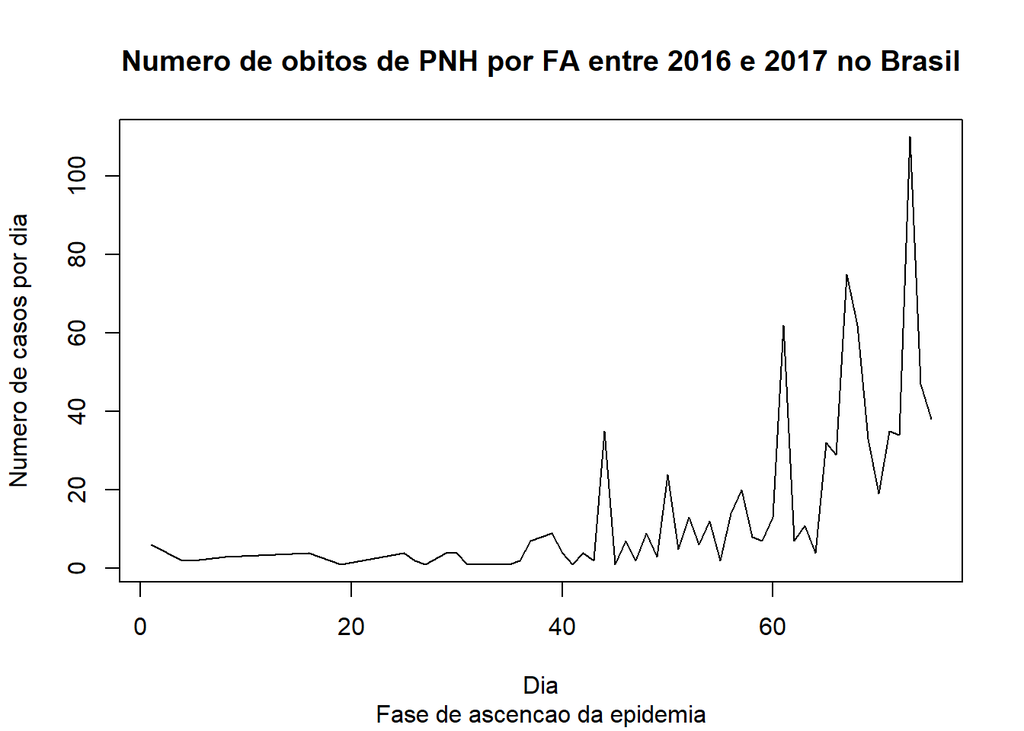

```r
plot(curve1$t, curve1$casos, type= "l", ylab = "Numero de casos por dia", xlab = "Dia",
     main = "Numero de obitos de PNH por FA entre 2016 e 2017 no Brasil",
     sub = "Fase de ascencao da epidemia")
```

```r
# Intervalo de tempo semanal
# Que não corresponde necessariamente à semana epidemiológica
sem <- c((curve1$t %/% 7)+1) # x %/% y = Parte inteira da divisão de x por y
curve2 <- data.frame(curve1$casos, sem)
curve2 <- group_by(curve2, sem)
curve2 <- summarise(curve2, sum(curve1.casos))
names(curve2) <- c("sem", "casos")
```

Ajuste da subida da curva utilizando uma funcao exponencial Ih = Ch x exp(k x tempo) onde Ch e k sao parametros de ajuste.

```r
ajuFA2 <- nls(casos ~ Ch*exp(k*sem), data = curve2,
              start = list(Ch=1, k=1),
              trace = TRUE)
```

```
## 4098789543 :  1 1
## 16785432 :  0.07420424 0.99368387
## 2006824 :  0.07845225 0.90378019
## 40603.01 :  0.1706769 0.7218919
## 29737.01 :  0.4488973 0.5558145
## 28976.13 :  0.6510177 0.5202729
## 28333.84 :  1.0916284 0.4704028
## 19460.07 :  1.9398663 0.4259047
## 3522.355 :  2.8206764 0.4259979
## 3522.34 :  2.8210949 0.4259543
## 3522.34 :  2.8208994 0.4259611
```

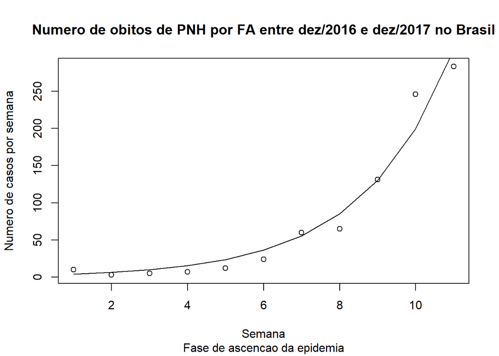

```r
plot(curve2$sem, curve2$casos, ylab = "Numero de casos por semana", xlab = "Semana",
     main = "Numero de obitos de PNH por FA entre dez/2016 e dez/2017 no Brasil",
     sub = "Fase de ascencao da epidemia", lines(predict(ajuFA2, list(x = curve2$sem))))
```

```r
coef(ajuFA2)
```

```
##        Ch         k
## 2.8208994 0.4259611
```

```r
k2 <- as.numeric(coef(ajuFA2)['k'])
k2
```

```
## [1] 0.4259611
```

## MODELAGEM

### Estimativas da população de primatas não humanos no Brasil

1. Os passos consistem em estimar o tamanho da área de floresta remanescente nos biomas onde houve registro de óbitos (Amazônia, Pantanal, Cerrado e Mata Atlântica).
2. Em seguida, multiplicar a área disponível pela densidade média da comunidade de primatas nesses biomas.
- Fonte de informação de área nativa remanescente para os biomas: http://www.fao.org/3/a-az172e.pdf
- Fonte de informação sobre a densidade de primatas no fragmento: Mata Atlântica: https://www.researchgate.net/publication/250038409_Densidade_e_tamanho_populacional_de_primatas_em_um_fragmento_florestal_no_sudeste_do_Brasil https://www.researchgate.net/publication/232240217_Densidade_tamanho_populacional_e_conservacao_de_primatas_em_fragmento_de_Mata_Atlantica_no_sul_do_Estado_de_Minas_Gerais_Brasil Amazônia: https://tede.ufam.edu.br/bitstream/tede/3613/1/Disserta%C3%A7%C3%A3o%20-%20L%C3%ADvia%20Rodrigues%20da%20Silva.pdf Pantanal e Cerrado: valores médios

Construindo um dataframe com as informações:

```r
biom <- c("Pantanal", "Amazon", "Cerrado", "Atlantic Forest")
area <- c(9376913, 354221815, 77929220, 22134124)
prim <- c(0.3, 0.9, 0.3, 0.3)
pnh.dens <- c(0.2246666, 0.215, 0.2246666, 0.2343333)
remain <- data.frame(biom, area, prim, pnh.dens)
remain
```

| biom | area | prim | pnh.dens |
| --- | --- | --- | --- |
| Pantanal | 9376913 | 0.3 | 0.2246666 |
| Amazon | 354221815 | 0.9 | 0.2150000 |
| Cerrado | 77929220 | 0.3 | 0.2246666 |
| Atlantic Forest | 22134124 | 0.3 | 0.2343333 |

Assim, a estimativa do tamanho da população de primatas nos biomas brasileiros:

```r
habitat <- remain$area*remain$prim
pop <- habitat*remain$pnh.dens
sum(pop)
```

```
## [1] 75982382
```

```r
pop.es <-  483158*0.3*0.2343333
pop.es
```

```
## [1] 33966
```

Nem toda a área vegetada disponível é habitada pelos primatas, dado que, em diferentes intensidades, esses animais são fortemente influenciados pela borda de mata. Por isso, apenas fragmentos com uma área *core* satisfatória podem ser usados para estimar a população real. É preciso refinar os dados de área remanescente nos biomas e da instensidade da fragmentação para obter a proporção habitável, e a partir daí, estimar a população total desses animais. Considerando uma letalidade média entre 80% e 90%, e assumindo que não há subnotificação, o total de casos de FA em PNH no ES foi:

```r
# selecionando os dados:
fa.es <- fa[fa$uf=="ES",]
sum(fa.es$casos)
```

```
## [1] 913
```

```r
# considerando que os óbitos representam 80% dos casos (alpha = 0.8):
casos.totais <- (sum(fa.es$casos)*100)/80
casos.totais # assumindo que não há subnotificação
```

```
## [1] 1141.25
```

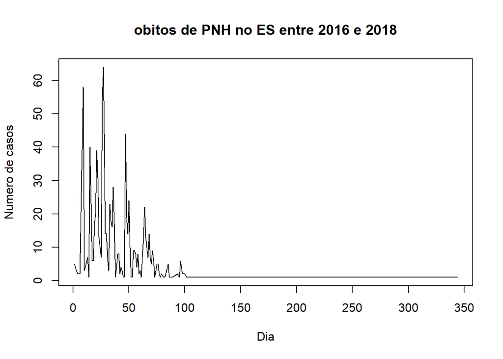

```r
# Convertendo data em vetor de valores inteiros (= contagem de dias):
fa.es$data <- ymd(fa.es$data)
fa.es <- arrange(fa.es,data)

inicio <- fa.es[1,1]
nextday <- as.integer(fa.es[,1] - inicio)
dia <- nextday+1
fa.es0 <- data.frame(fa.es,dia)

# Nesse novo df, agrupar o número de registros por dia:
fa.es0 <- group_by(fa.es0, dia)
curve.es <- summarise(fa.es0,sum(casos))
names(curve.es) <- c("dia", "casos")

plot(y = curve.es$casos, x = curve.es$dia, type="l", main = "obitos de PNH no ES entre 2016 e 2018", xlab = "Dia", ylab = "Numero de casos")
```

### Modelo determinístico para doença transmitida por vetores (SIR/SI)

A formulação apresentada a seguir presupõe que as populações sejam constantes.

```r
library(deSolve)
```

A proposta a seguir é reproduzir o padrão da epizootia de febre amarela ocorrida no estado do Espírito Santo entre dezembro de 2016 e março de 2018, utilizando os parâmetros estimados por Massad et al (2018) no artigo intitulado *The risk of urban yellow fever resurgence in Aedes-infested American cities*. No artigo as taxas são apresentadas por mês, e aqui foram convertidos para taxas diárias, conforme abaixo:

```r
a <- 0.137 # taxa de picadas
b <- 0.6062 # fracao de picadas infectantes
c <- 0.5265 # suscetibilidade do Ae. aegypti a YF
gamam <- 0.01072 # taxa de latencia em Ae. aegypti a YF
mum <- 0.0777 # taxa de mortalidade natural de mosquitos
```

Mesmo que o número de casos nos dados utilizados abranja todas as espécies de primatas não humanos acometidas, a taxa de mortalidade natural corresponde à média para os três gêneros mais afetados pela febre amarela: *Alouatta*, *Callithrix* e *Cebus* (~1/25 anos). A taxa de recuperação utilizada foi obtida do mesmo artigo citado anteriormente, referente aos hospedeiros humanos, dada a escassez de dados específicos para os PNH.

```r
muh <- 1.096e-4 # taxa de mortalidade natural de *PNH* (1/25 anos)
gamah <- 0.01072 # taxa de recuperacao YF em *humanos*
alfah <-  0.198 # taxa de letalidade por YF em *humanos* ~ 0.198

par.vetor <- c(a=a, b=b, c=c, muh=muh, gamah=gamah, alfah=alfah, gamam=gamam, mum=mum)
```

Estabelecendo o vetor com as variáveis e as condições iniciais:

```r
Sh0 <- 34000
Sm0 <- 1020000
m <- Sm0/Sh0 # Ross sugere limiar = 1.5

R0 <- a*a*b*c*m*gamam/(mum*(mum+gamam)*(muh+alfah+gamah))
R0
```

```
## [1] 1.342789
```

```r
state.vetor <- c(Sh=Sh0,Ih=5,Rh=0,Sm=Sm0,Lm=0,Im=0)
```

```r
# Tempo de simulacao
tsim <- 5*365
Dt <- 1
```

A função abaixo corresponde ao modelo de Ross-Macdonald, cujo termo de transmissão é frequência dependente, para mosquitos adultos. Neste modelo, sendo considerado o pressuposto de população constante, a taxa de natalidade equivale à soma das taxas de mortalidade natural incidentes sobre cada compartimento (muh x Sh + muh x Ih + muh x Rh = muh = natalidade).

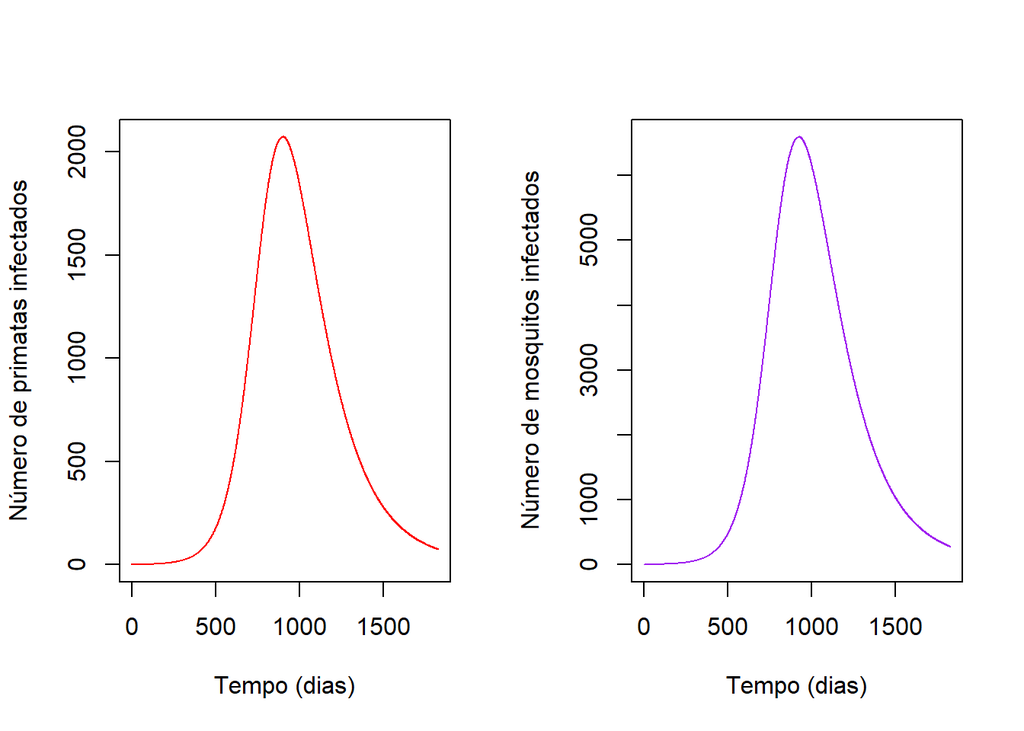

```r
mod.vetor <- function(t,state,parameters){
        with(as.list(c(state,parameters)),{

                # Equacoes para hospedeiros
                dSh <- - a*b*Im*(Sh/(Sh+Ih+Rh)) + muh*Ih + muh*Rh + alfah*Ih
                dIh <- a*b*Im*(Sh/(Sh+Ih+Rh)) - gamah*Ih - muh*Ih - alfah*Ih
                dRh <- gamah*Ih - muh*Rh

                # Equacoes para vetores
                dSm <- -a*c*Sm*(Ih/(Sh+Ih+Rh)) + mum*Lm + mum*Im
                dLm <- a*c*Sm*(Ih/(Sh+Ih+Rh)) - (gamam + mum)*Lm
                dIm <- gamam*Lm - mum*Im

                # return the output of the model
                return(list(c(dSh, dIh, dRh, dSm, dLm, dIm)))

        })
}

tempos <- seq(from=0,to=tsim,by=Dt)

mod <- ode(y = state.vetor, times = tempos, func = mod.vetor, parms = par.vetor, method = "ode45")

# Criando um dataframe com os resultados:
mod <- as.data.frame(mod)
names(mod) <- c("t","Sh", "Ih", "Rh", "Sm", "Lm", "Im")

# Grafico de infectados
par(mfrow=c(1,2))
plot(mod$t, mod$Ih, col="red", type="l",
     xlab="Tempo (dias)", ylab="Número de primatas infectados")
plot(mod$t, mod$Im, col="purple", type="l",
     xlab="Tempo (dias)", ylab="Número de mosquitos infectados")
```

## CONSIDERAÇÕES FINAIS

Os motivos pelos quais a simulação não reproduz exatamente o gráfico de registros de óbitos de pnh para o ES podem ser muitos:

- Em primeiro lugar, as taxas utilizadas são estimadas a partir do surto de Dengue no Rio de Janeiro em 2012. Ou seja, as espécies de vetor, hospedeiro e patógeno, assim como o ambiente, são diferentes.
- Em segundo lugar, a imprecisão dos registros pode ocultar a realidade do evento. Subnotificações e outras dificuldades mascaram aspectos importantes.
- Entretanto, a modelagem pode sugerir o que os dados não apresentam: a quantidade de indivíduos infectados durante o surto.